# Gráficos con ggplot2: algunos gráficos sencillos

Módulo práctico de ITA  
(Grupo M)

Pedro J. Pérez

pedro.j.perez@uv.es

## Gráficos sencillos con *ggplot2*

Ya tenemos las primeras ideas de ggplot2. Ahora vamos a hacer algunos gráficos sencillos, pero de distintos tipos: de líneas, de puntos (X-Y) y de barras. Y al final veremos cómo llevarlos a Word o a Excel.

## antes de empezar

- Usaremos los datos de **gapminder**, que ya conocéis de las slides de manejo de datos

```r
gapminder <- gapminder::gapminder
```

- Casi siempre haremos lo mismo: **primero preparamos los datos** (con `dplyr`) y **después hacemos el gráfico** (con `ggplot2`)
- ¿Te acuerdas? Datos (ggplot()) + estéticas (aes()) + elemento geométrico (geom_xx()). De un tipo de gráfico a otro **lo que cambia es, sobre todo, el `geom_xx()`**:

| tipo de gráfico | geom |
| --- | --- |
| líneas | `geom_line()` |
| puntos (X-Y) | `geom_point()` |
| barras | `geom_col()` |

## Gráficos de líneas

Sirven, sobre todo, para ver cómo evoluciona una variable a lo largo del tiempo

## primero, los datos

Queremos ver cómo ha evolucionado la **esperanza de vida en España**. Así que primero nos quedamos con las filas de España:

```r
df_spain <- gapminder %>%
  filter(country == "Spain")
```

```r
gt::gt(head(df_spain, n = 6))
```

| country | continent | year | lifeExp | pop | gdpPercap |
| --- | --- | --- | --- | --- | --- |
| Spain | Europe | 1952 | 64.94 | 28549870 | 3834.035 |
| Spain | Europe | 1957 | 66.66 | 29841614 | 4564.802 |
| Spain | Europe | 1962 | 69.69 | 31158061 | 5693.844 |
| Spain | Europe | 1967 | 71.44 | 32850275 | 7993.512 |
| Spain | Europe | 1972 | 73.06 | 34513161 | 10638.751 |
| Spain | Europe | 1977 | 74.39 | 36439000 | 13236.921 |

- Tenemos una fila por año: en el **eje X** pondremos el año (`year`) y en el **eje Y** la esperanza de vida (`lifeExp`)

## un gráfico de líneas, paso a paso

```r
ggplot(data = df_spain) +
```

```r
ggplot(data = df_spain) +
  aes(x = year) +
```

```r
ggplot(data = df_spain) +
  aes(x = year) +
  aes(y = lifeExp) +
```

```r
ggplot(data = df_spain) +
  aes(x = year) +
  aes(y = lifeExp) +
  geom_line() +
```

```r
ggplot(data = df_spain) +
  aes(x = year) +
  aes(y = lifeExp) +
  geom_line() +
  geom_point() +
```

```r
ggplot(data = df_spain) +
  aes(x = year) +
  aes(y = lifeExp) +
  geom_line() +
  geom_point() +
  labs(title = "Evolución de la esperanza de vida (España)",
       x = NULL,
       y = "años")
```

`labs()` pone el **título** del gráfico y los **nombres de los ejes**

- Con `NULL`, el eje x se queda sin nombre

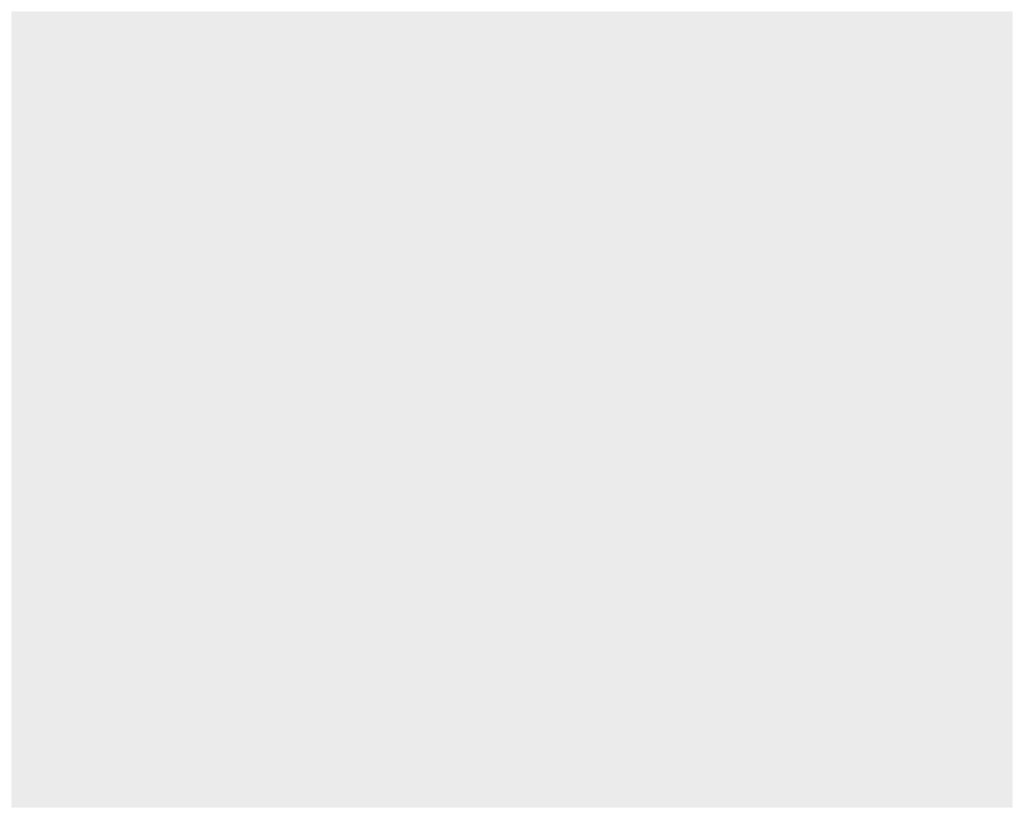

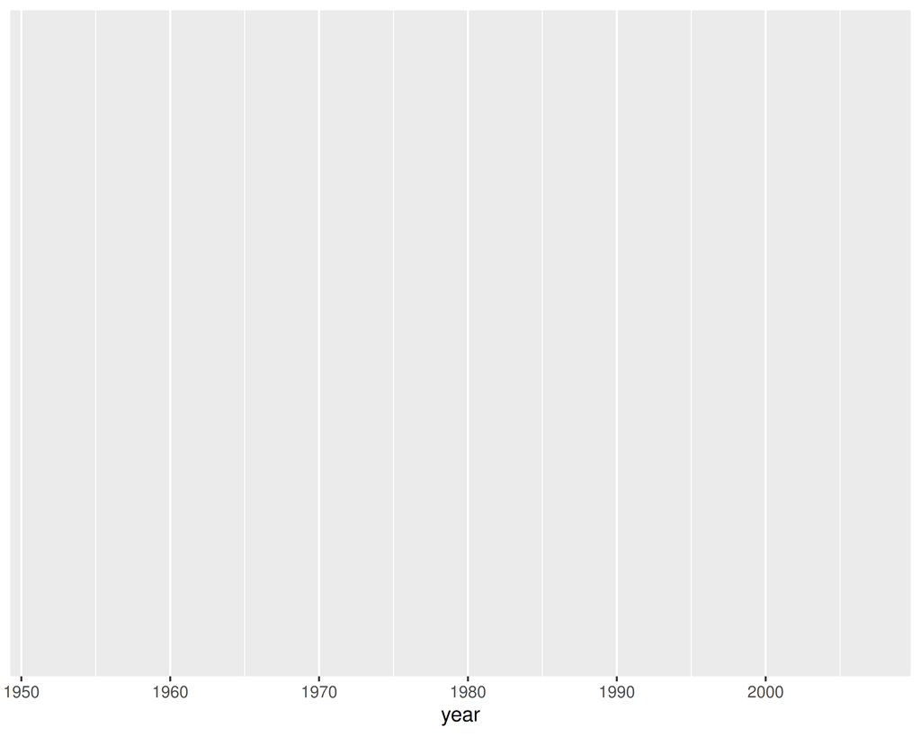

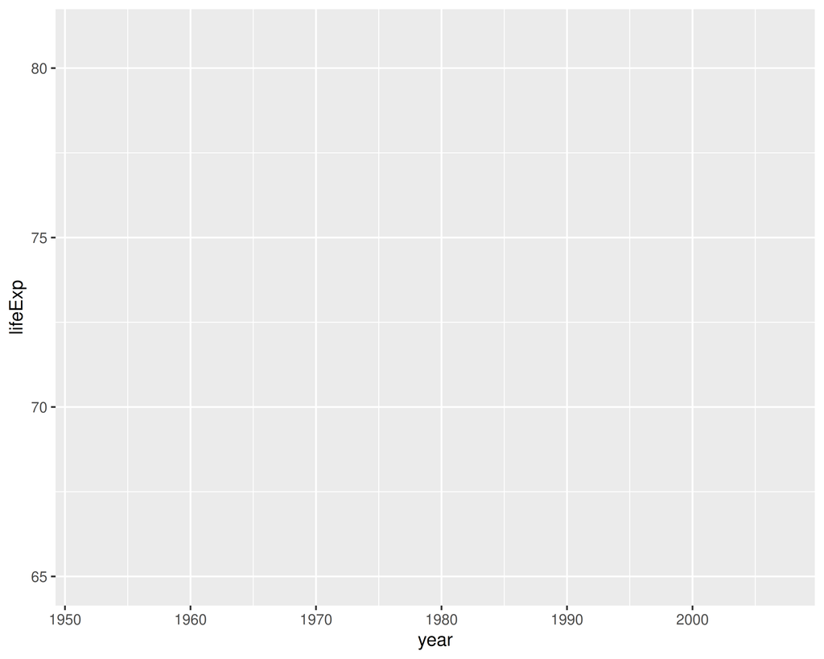

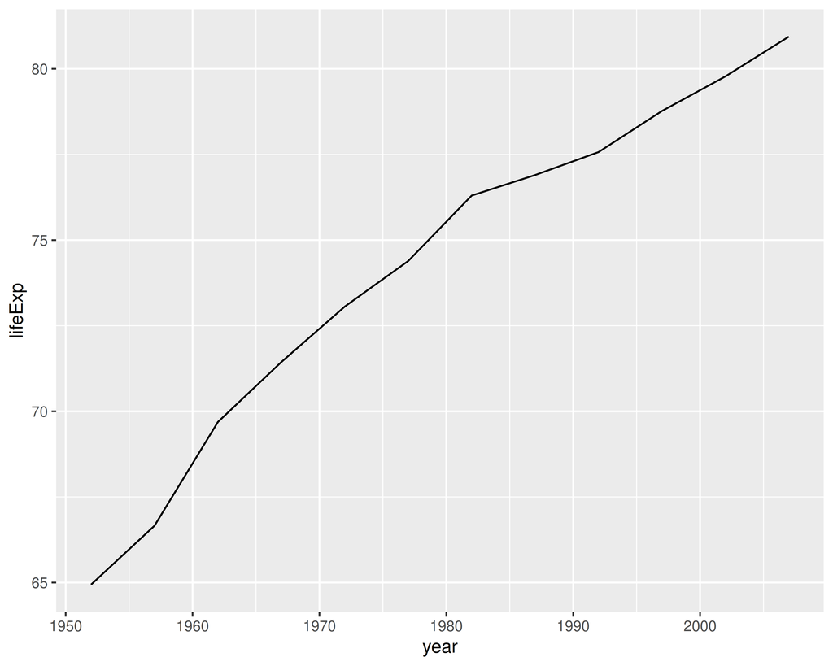

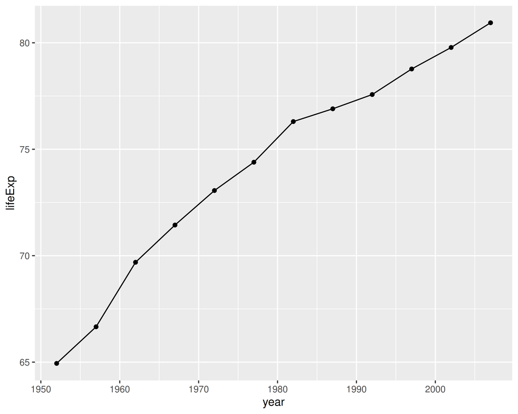

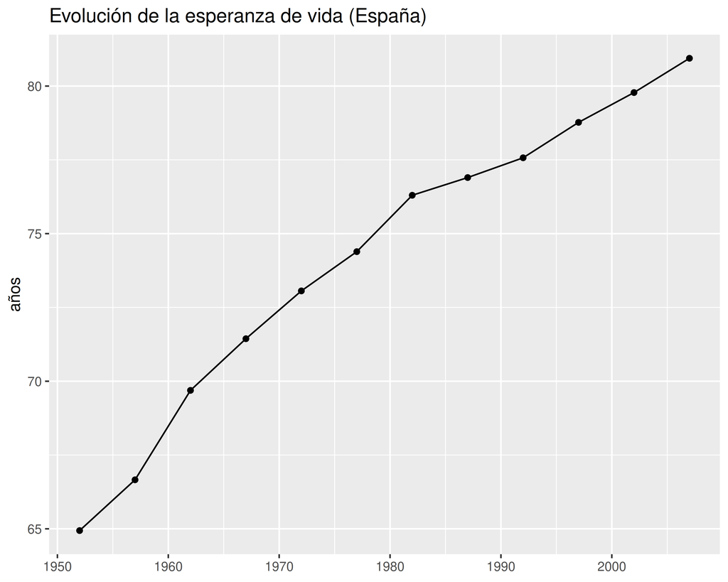

## varias líneas: una por país

Queremos **comparar varios países**.

Fíjate en `color = country`. Está **dentro de `aes()`**, así que el color depende de la variable `country`; por lo tanto, tendremos un color de linea por país

- Una línea por país
- Con puntos y títulos

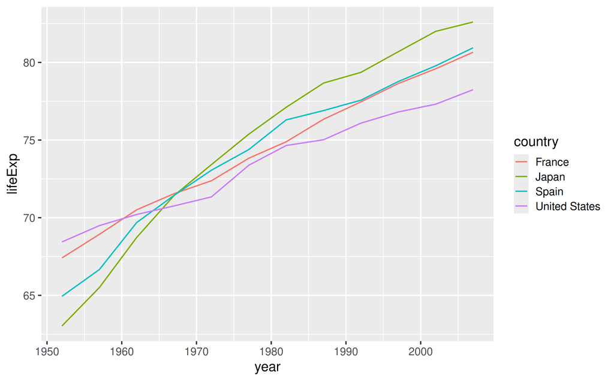

```r
df_paises <- gapminder %>%
  filter(country %in% c("Spain", "France",
                        "United States", "Japan"))

ggplot(data = df_paises,
       aes(x = year, y = lifeExp,
           color = country)) +
  geom_line()
```

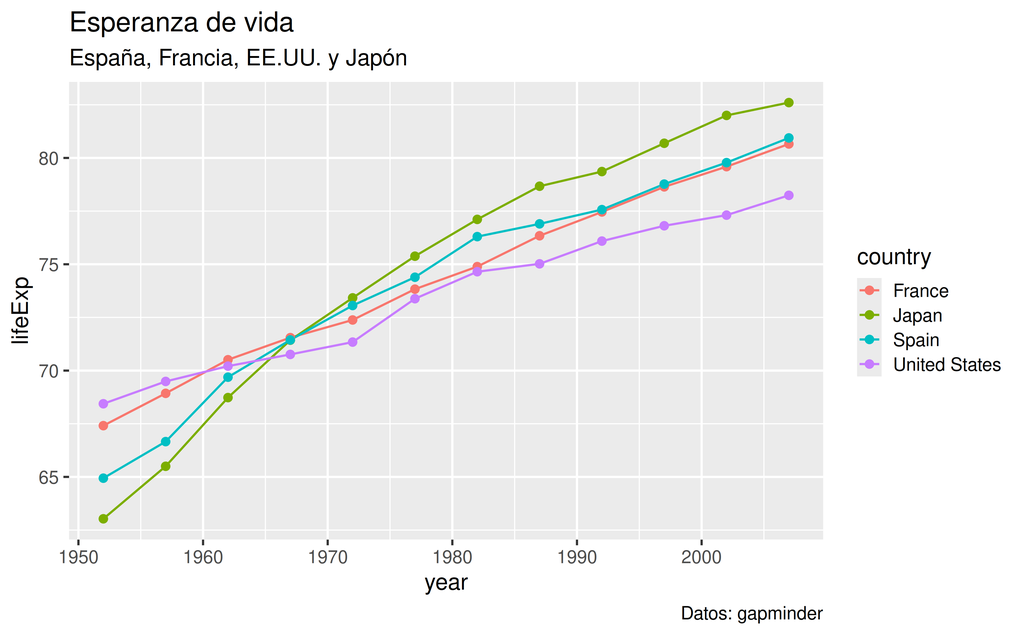

```r
ggplot(data = df_paises,
       aes(x = year, y = lifeExp,
           color = country)) +
  geom_line() +
  geom_point() +
  labs(title = "Esperanza de vida",
       subtitle = "España, Francia, EE.UU. y Japón",
       caption = "Datos: gapminder")
```

¿Qué pasará si quitas `color = country`? Pruébalo. ¿Ves el problema? ggplot2 uniría todos los puntos con una sola línea

## Gráficos X-Y

Gráficos de puntos (o de dispersión): sirven para ver la relación entre dos variables. Cada punto es una observación

## primero, los datos

¿Los países más ricos tienen una esperanza de vida más alta? Para verlo nos quedamos **con un solo año**, el último (2007): así tenemos un punto por país

```r
df_2007 <- gapminder %>%
  filter(year == 2007) %>%
  mutate(pob_millones = pop / 1000000)

nrow(df_2007)  #- 142 países: 142 puntos
```

```
#> [1] 142
```

- En el **eje X** pondremos la renta per cápita (`gdpPercap`) y en el **eje Y** la esperanza de vida (`lifeExp`)
- … y como tenemos más variables, podemos usar más estéticas: el **color** para el continente y el **tamaño** de los puntos para la población (en millones, para que la leyenda se lea mejor)

## un gráfico X-Y, paso a paso

```r
ggplot(data = df_2007) +
```

```r
ggplot(data = df_2007) +
  aes(x = gdpPercap) +
```

```r
ggplot(data = df_2007) +
  aes(x = gdpPercap) +
  aes(y = lifeExp) +
```

```r
ggplot(data = df_2007) +
  aes(x = gdpPercap) +
  aes(y = lifeExp) +
  geom_point() +
```

```r
ggplot(data = df_2007) +
  aes(x = gdpPercap) +
  aes(y = lifeExp) +
  geom_point() +
  aes(color = continent) +
```

```r
ggplot(data = df_2007) +
  aes(x = gdpPercap) +
  aes(y = lifeExp) +
  geom_point() +
  aes(color = continent) +
  aes(size = pob_millones) +
```

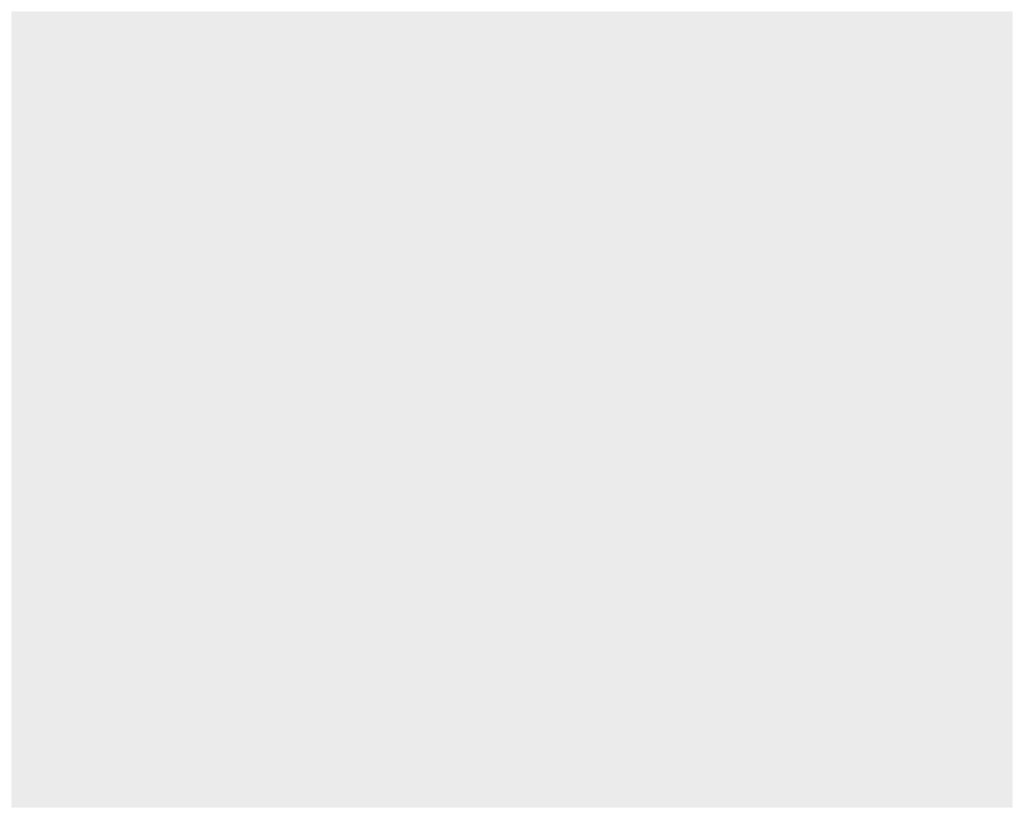

```r
ggplot(data = df_2007) +
  aes(x = gdpPercap) +
  aes(y = lifeExp) +
  geom_point() +
  aes(color = continent) +
  aes(size = pob_millones) +
  labs(title = "Renta y esperanza de vida (2007)",
       x = "renta per cápita",
       y = "esperanza de vida")
```

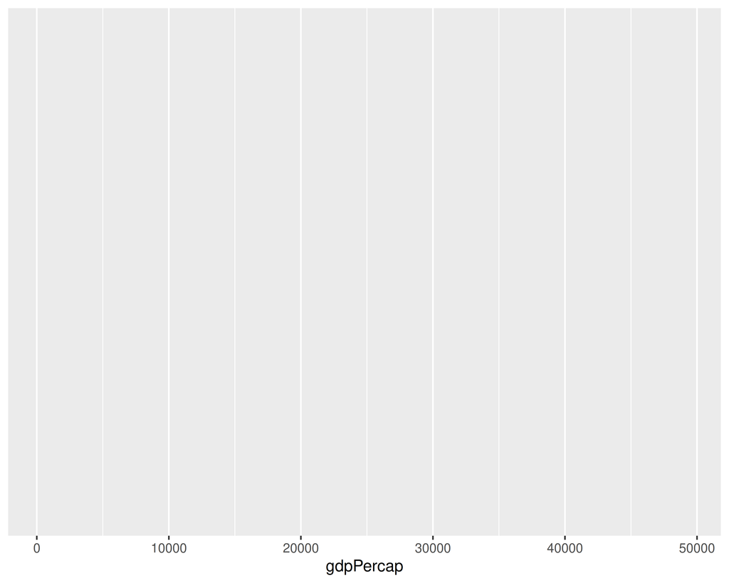

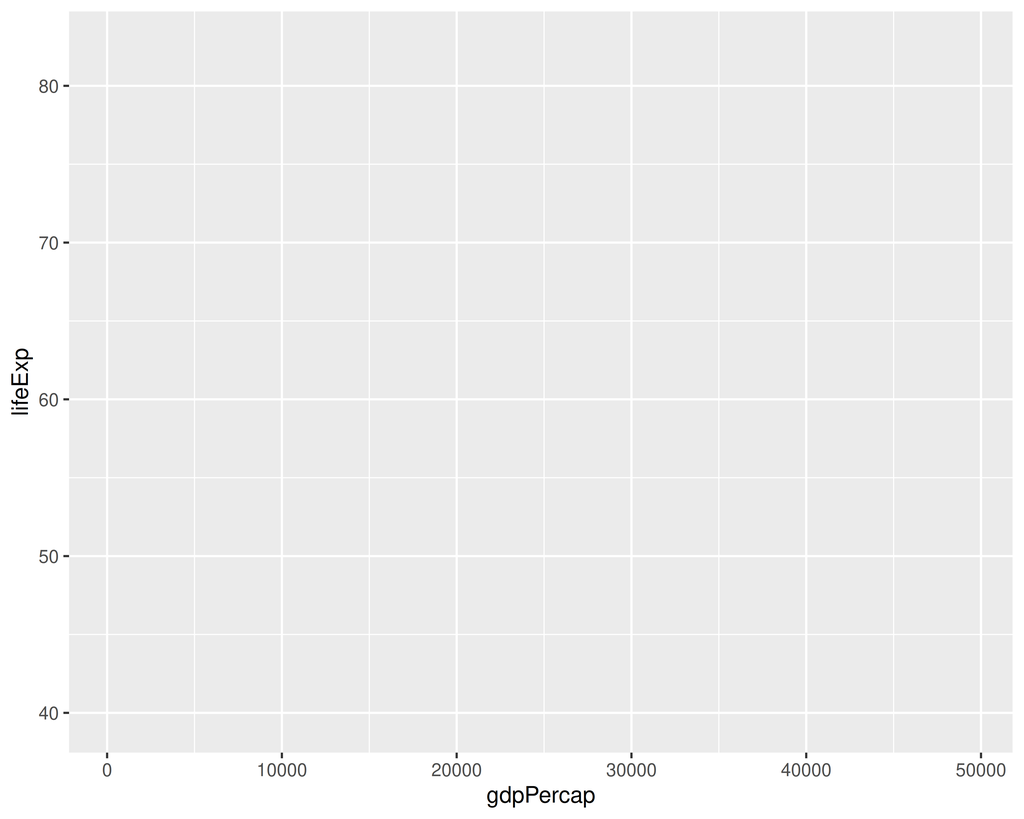

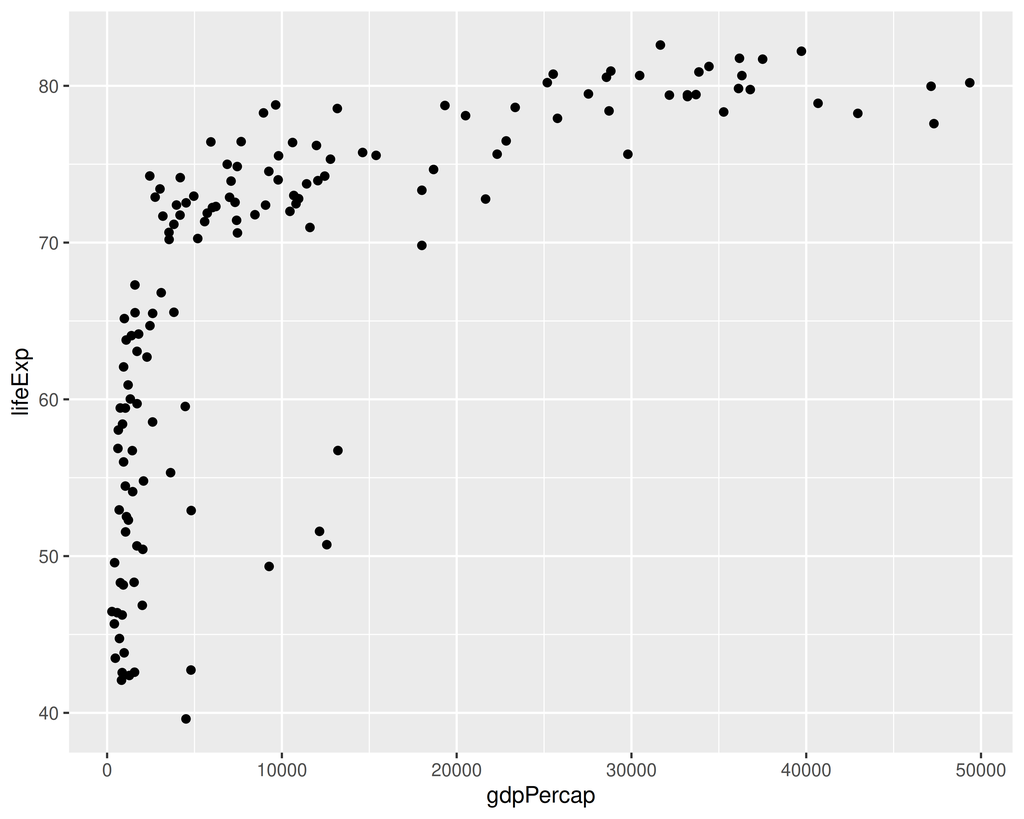

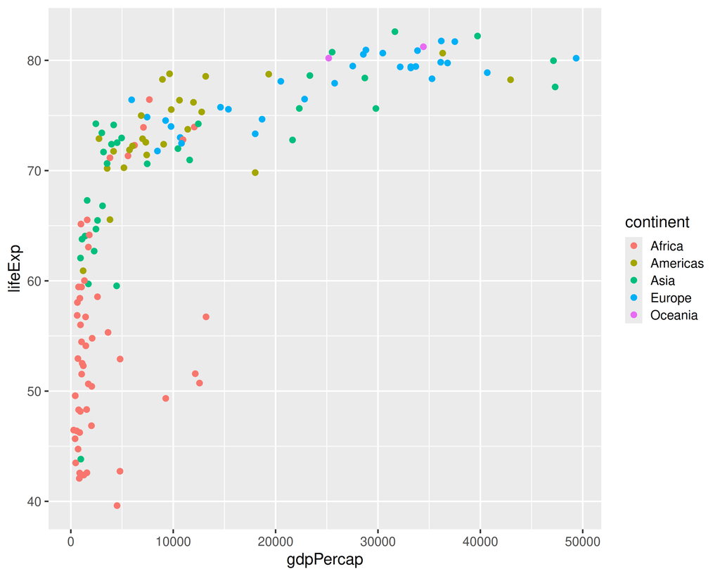

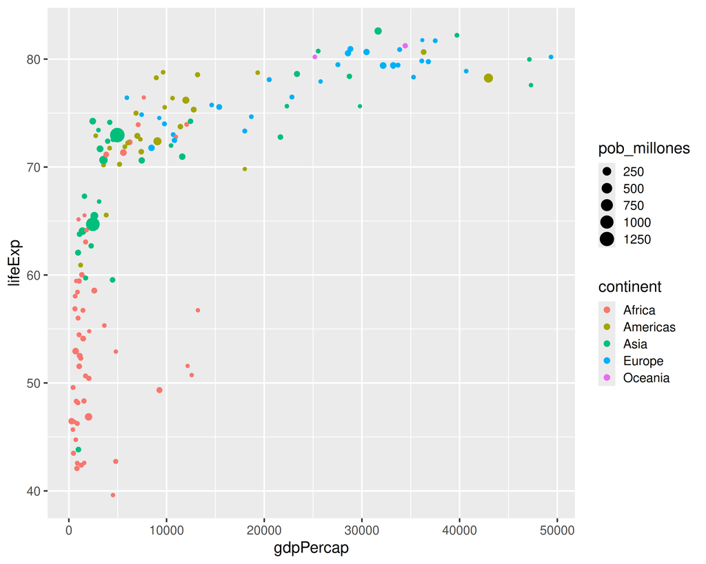

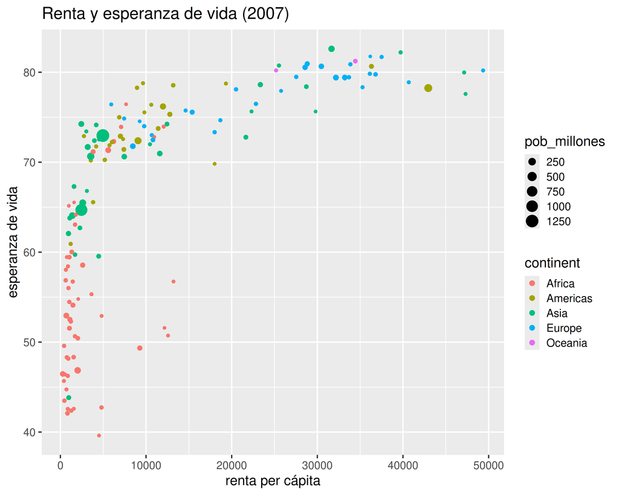

## Gráficos de barras

Sirven para comparar un valor entre distintos grupos: por ejemplo, la población de cada continente

## `geom_col()`: la altura de las barras ya la tenemos

Queremos un gráfico con la **población de cada continente** en 2007. Primero la calculamos (¿te acuerdas de `group_by()` + `summarise()`?) y después hacemos el gráfico

```r
df_pob <- df_2007 %>%
  group_by(continent) %>%
  summarise(pob = round(sum(pop) / 1000000))

gt::gt(df_pob)
```

| continent | pob |
| --- | --- |
| Africa | 930 |
| Americas | 899 |
| Asia | 3812 |
| Europe | 586 |
| Oceania | 25 |

… y ahora el gráfico:

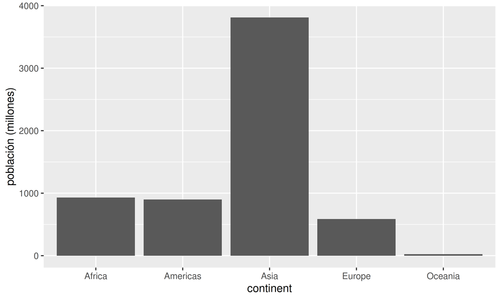

```r
ggplot(data = df_pob,
       aes(x = continent, y = pob)) +
  geom_col() +
  labs(y = "población (millones)")
```

- Con `geom_col()` la altura de cada barra es **un valor que ya está en los datos** (aquí, la columna `pob`)

## barras horizontales (y ordenadas)

Con nombres largos o muchos grupos, las **barras horizontales** se leen mejor. Basta con poner los grupos en el **eje Y**. Y con `reorder()` ordenamos las barras según su valor

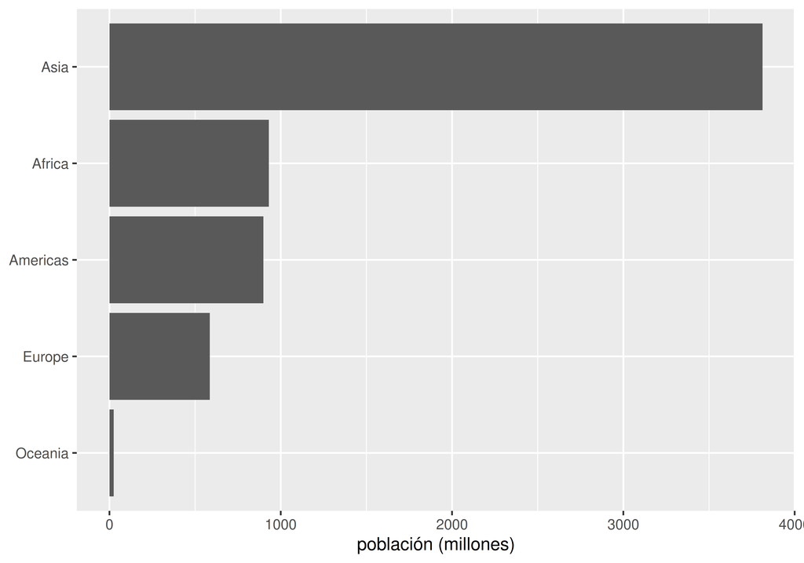

```r
ggplot(data = df_pob,
       aes(x = pob,
           y = reorder(continent, pob))) +
  geom_col() +
  labs(x = "población (millones)",
       y = NULL)
```

- `reorder(continent, pob)`: ordena los continentes según su población

## barras de colores: ¿dentro o fuera de `aes()`?

En las barras, el color del relleno es la estética **`fill`** (`color` es el color del borde de las barritas). Como siempre, puede ir dentro o fuera de `aes()`:

**Dentro** de `aes()`: el color depende de una variable (el continente)

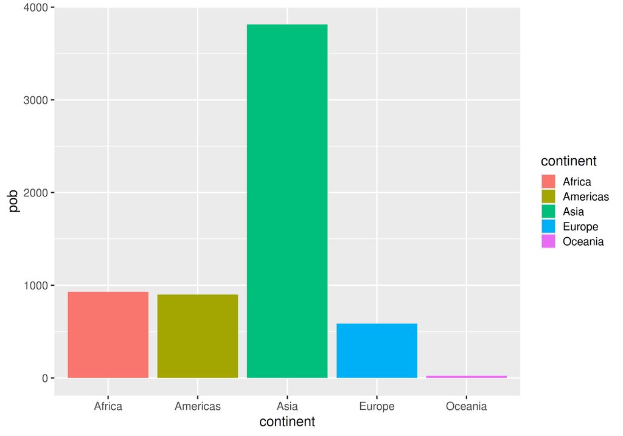

```r
ggplot(data = df_pob,
       aes(x = continent, y = pob)) +
  geom_col(aes(fill = continent))
```

**Fuera** de `aes()`: todas las barras del mismo color

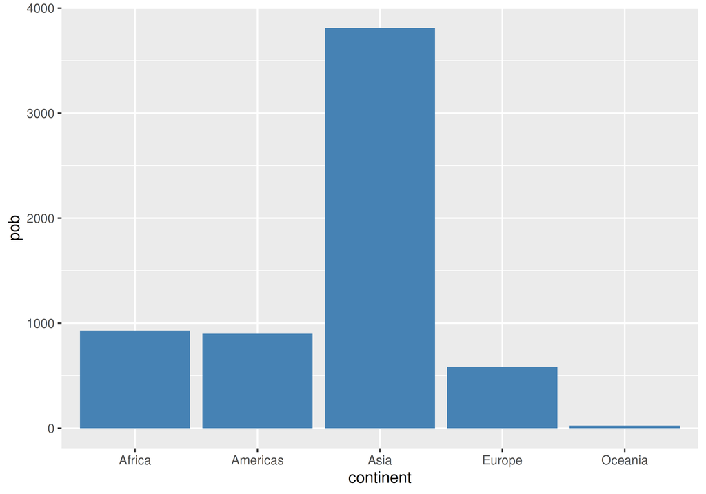

```r
ggplot(data = df_pob,
       aes(x = continent, y = pob)) +
  geom_col(fill = "steelblue")
```

## Tarea: haz tú los gráficos

- Tarea
- Pistas
- Solución 1
- Solución 2
1. Haz un **gráfico de líneas** con la evolución de la renta per cápita (`gdpPercap`) de España, Portugal e Italia
2. Haz un **gráfico de barras** con la esperanza de vida media (`lifeExp`) de cada continente en 2007
- Para el 1: es igual que el de varios países, pero cambiando los países y la variable del eje Y
- Para el 2: primero hay que calcular la media de cada continente, con `group_by()` y `summarise()`. Después, como ya tienes la altura de las barras, `geom_col()`

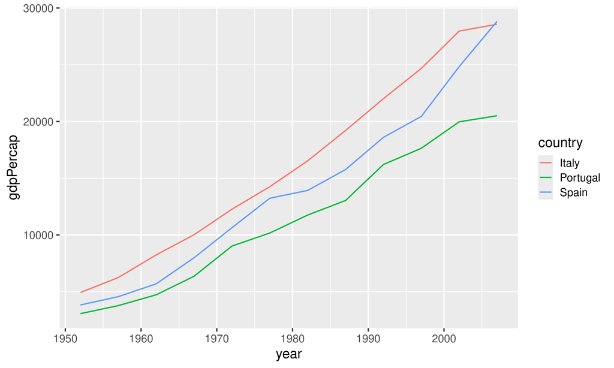

```r
df_tarea <- gapminder %>%
  filter(country %in% c("Spain", "Portugal", "Italy"))

ggplot(data = df_tarea, aes(x = year, y = gdpPercap, color = country)) +
  geom_line()
```

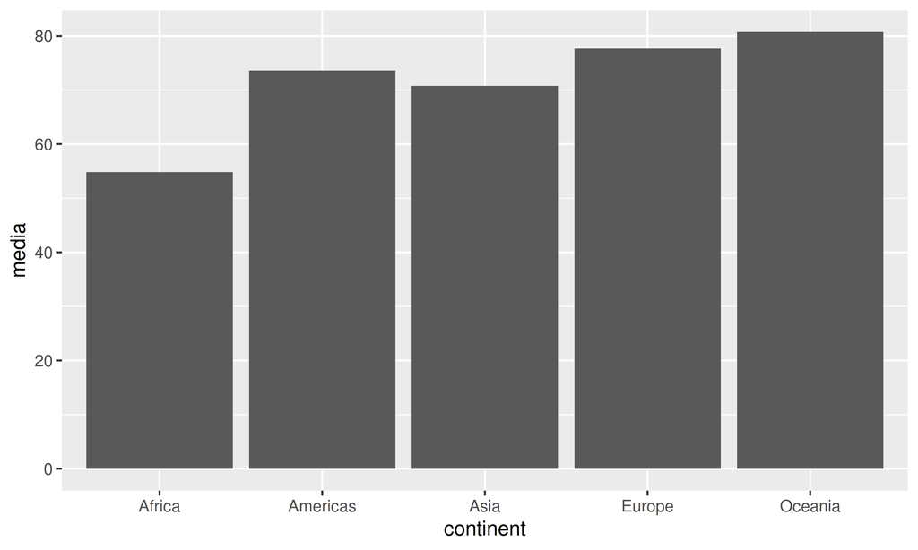

```r
df_tarea <- df_2007 %>%
  group_by(continent) %>%
  summarise(media = mean(lifeExp))

ggplot(data = df_tarea, aes(x = continent, y = media)) +
  geom_col()
```

## Exportar los gráficos

Hacer el gráfico está muy bien, pero muchas veces lo queremos meter en un informe (Word) o en una hoja de cálculo (Excel). Veamos cómo

## primero: guardar el gráfico en un fichero

Lo más cómodo es guardar el gráfico en un fichero de imagen con `ggsave()`

```r
p <- ggplot(data = df_spain, aes(x = year, y = lifeExp)) +
  geom_line()

ggsave("grafico_spain.png",
       plot = p,
       width = 16, height = 10, units = "cm",
       dpi = 300)
```

**1**

Guardamos el gráfico en un objeto, `p`

**2**

El nombre del fichero: la extensión decide el formato (`.png`, `.jpg`, `.pdf` …)

**3**

El tamaño de la imagen: aquí 16 x 10 cm

**4**

La resolución: con 300 se ve bien incluso impreso

- El fichero se guarda en la **carpeta del proyecto**. Búscalo en la pestaña *Files* de RStudio
- Consejo: pon en `width` y `height` el tamaño que tendrá el gráfico en el documento. Así las letras salen con un tamaño razonable

## llevar el gráfico a Word

- Una vez tienes el fichero `.png`, en Word: **Insertar > Imágenes > Este dispositivo** … y eliges el fichero
- … o, más fácil aún, **arrastras el fichero** al documento

un atajo (con truco)

- En RStudio, en la pestaña *Plots*: **Export > Copy to Clipboard…** y después, en Word, **Ctrl + V**
- Es más rápido, pero el tamaño y la calidad del gráfico los controlas peor. Para un trabajo que vas a entregar, mejor `ggsave()`

## llevar el gráfico a Excel

Aquí tenemos **2 opciones**:

1. **Meter la imagen**, igual que en Word: en Excel, **Insertar > Imágenes**
   - Pero ojo: es una imagen, así que en Excel no podrás cambiar nada del gráfico
2. **Exportar los datos a Excel** y hacer allí el gráfico. ¿Te acuerdas de `rio::export()`?

```r
rio::export(df_pob, "poblacion_continentes.xlsx")
```

- Después, en Excel, seleccionas los datos e **Insertar > Gráficos**. Lo veremos en las slides de Excel

¿Cuál es mejor? Depende: si el gráfico ya está terminado, la imagen; si en Excel lo quieres modificar (o actualizar), los datos

## Tarea: exporta tus gráficos

1. Guarda con `ggsave()` los dos gráficos de la tarea anterior. Elige tú el tamaño
2. Abre un documento de Word y mete en él los dos gráficos
3. Exporta a Excel los datos del gráfico de barras (la esperanza de vida media de cada continente) y haz allí un gráfico de barras
- ¿Qué te ha resultado más fácil? ¿Y qué gráfico queda mejor, el de R o el de Excel?

## Resumen

- **Primero preparamos los datos** (con `dplyr`) y **después hacemos el gráfico** (con `ggplot2`)
- Lo que cambia de un tipo de gráfico a otro es, sobre todo, el `geom_xx()`:
  - **líneas**: `geom_line()`; con `color` hacemos una línea por grupo
  - **puntos (X-Y)**: `geom_point()`
  - **barras**: `geom_col()` si ya tenemos la altura de las barras
- Para **exportar** un gráfico: `ggsave()` y después lo metemos en Word o Excel. A Excel también podemos llevar los datos, con `rio::export()`